## Report: act_report

- Create a **250-word-minimum written report** called "act_report.pdf" or "act_report.html" that communicates the insights and displays the visualization(s) produced from your wrangled data. This is to be framed as an external document, like a blog post or magazine article, for example.

# Insights

1. Which dog has the highest favorites count - The first insight shows the dog that is the favorite of all dogs i.e out of over 1000 dogs, which one had the most favorite count. The answer to this insight is :The dog that has the highest favorites count have an ID of 744234799360020481, a rating of 13, a breed of Labrador_retriever and is a doggo.

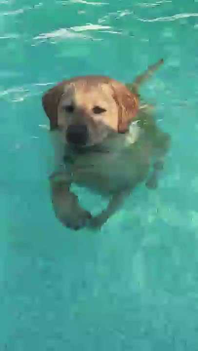

1. Which dog was retweeted the most - This second insight focuses on the highest number of times people retweets a dog. The answer to this insight is :The dog that has the highest retweets count is the same as the one that has the highest favorites count i.e has an ID of 744234799360020481, a rating of 13 and is a doggo and a breed of Labrador retrieval.

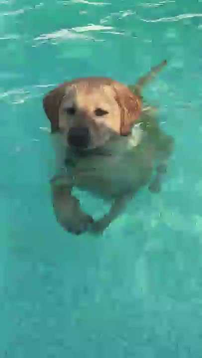

1. The first and second insight talked about the highest counts. What if we want to know the dog that had the least favorites count? That brings us to the third insight:The dog that has the lowest favorites count have an ID of 666102155909144576 and is a breed of English setter, Newfoundland and Borzoi with a rating of 11.

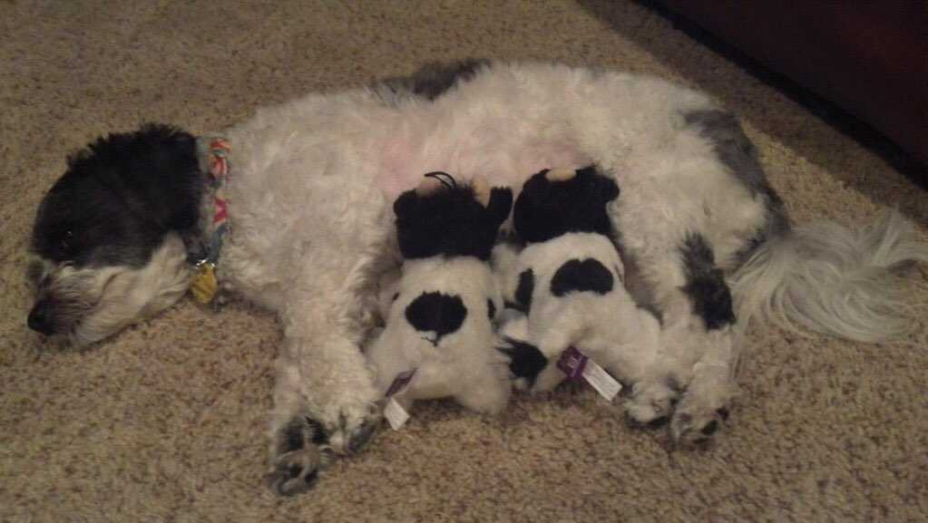

# Visualization

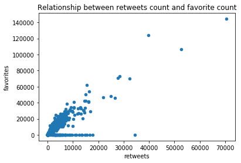